# Risk Factor Analysis

## Outcome Variable

**Outcome Variable:** sstunted

## Predictor Variables

**Intervention Variable:** feducyrs

**Adjustment Set:**

unadjusted

## Stratifying Variables

The analysis was stratified on these variable(s):

- agecat
- studyid
- country

## Data Summary

| agecat | studyid | country | feducyrs | sstunted | n_cell | n |
| --- | --- | --- | --- | --- | --- | --- |
| Birth | ki0047075b-MAL-ED | BANGLADESH | High | 0 | 44 | 129 |
| Birth | ki0047075b-MAL-ED | BANGLADESH | High | 1 | 3 | 129 |
| Birth | ki0047075b-MAL-ED | BANGLADESH | Low | 0 | 35 | 129 |
| Birth | ki0047075b-MAL-ED | BANGLADESH | Low | 1 | 1 | 129 |
| Birth | ki0047075b-MAL-ED | BANGLADESH | Medium | 0 | 44 | 129 |
| Birth | ki0047075b-MAL-ED | BANGLADESH | Medium | 1 | 2 | 129 |
| Birth | ki0047075b-MAL-ED | INDIA | High | 0 | 7 | 24 |
| Birth | ki0047075b-MAL-ED | INDIA | High | 1 | 0 | 24 |
| Birth | ki0047075b-MAL-ED | INDIA | Low | 0 | 13 | 24 |
| Birth | ki0047075b-MAL-ED | INDIA | Low | 1 | 1 | 24 |
| Birth | ki0047075b-MAL-ED | INDIA | Medium | 0 | 3 | 24 |
| Birth | ki0047075b-MAL-ED | INDIA | Medium | 1 | 0 | 24 |
| Birth | ki0047075b-MAL-ED | NEPAL | High | 0 | 3 | 10 |
| Birth | ki0047075b-MAL-ED | NEPAL | High | 1 | 0 | 10 |
| Birth | ki0047075b-MAL-ED | NEPAL | Low | 0 | 3 | 10 |
| Birth | ki0047075b-MAL-ED | NEPAL | Low | 1 | 1 | 10 |
| Birth | ki0047075b-MAL-ED | NEPAL | Medium | 0 | 3 | 10 |
| Birth | ki0047075b-MAL-ED | NEPAL | Medium | 1 | 0 | 10 |
| Birth | ki0047075b-MAL-ED | PERU | High | 0 | 85 | 194 |
| Birth | ki0047075b-MAL-ED | PERU | High | 1 | 1 | 194 |
| Birth | ki0047075b-MAL-ED | PERU | Low | 0 | 57 | 194 |
| Birth | ki0047075b-MAL-ED | PERU | Low | 1 | 1 | 194 |
| Birth | ki0047075b-MAL-ED | PERU | Medium | 0 | 49 | 194 |
| Birth | ki0047075b-MAL-ED | PERU | Medium | 1 | 1 | 194 |
| Birth | ki0047075b-MAL-ED | SOUTH AFRICA | High | 0 | 10 | 33 |
| Birth | ki0047075b-MAL-ED | SOUTH AFRICA | High | 1 | 0 | 33 |
| Birth | ki0047075b-MAL-ED | SOUTH AFRICA | Low | 0 | 14 | 33 |
| Birth | ki0047075b-MAL-ED | SOUTH AFRICA | Low | 1 | 0 | 33 |
| Birth | ki0047075b-MAL-ED | SOUTH AFRICA | Medium | 0 | 9 | 33 |
| Birth | ki0047075b-MAL-ED | SOUTH AFRICA | Medium | 1 | 0 | 33 |

[output cut: 300 more lines]

The following strata were considered:

- agecat: 24 months, studyid: ki0047075b-MAL-ED, country: BANGLADESH
- agecat: 24 months, studyid: ki0047075b-MAL-ED, country: INDIA
- agecat: 24 months, studyid: ki0047075b-MAL-ED, country: NEPAL
- agecat: 24 months, studyid: ki0047075b-MAL-ED, country: PERU
- agecat: 24 months, studyid: ki0047075b-MAL-ED, country: SOUTH AFRICA
- agecat: 24 months, studyid: ki0047075b-MAL-ED, country: TANZANIA, UNITED REPUBLIC OF
- agecat: 24 months, studyid: ki1017093b-PROVIDE, country: BANGLADESH
- agecat: 24 months, studyid: ki1017093c-NIH-Crypto, country: BANGLADESH
- agecat: 24 months, studyid: ki1066203-TanzaniaChild2, country: TANZANIA, UNITED REPUBLIC OF
- agecat: 24 months, studyid: ki1113344-GMS-Nepal, country: NEPAL
- agecat: 24 months, studyid: ki1119695-PROBIT, country: BELARUS
- agecat: 24 months, studyid: ki1126311-ZVITAMBO, country: ZIMBABWE
- agecat: 24 months, studyid: ki1135781-COHORTS, country: GUATEMALA
- agecat: 24 months, studyid: ki1135781-COHORTS, country: INDIA
- agecat: 24 months, studyid: ki1135781-COHORTS, country: PHILIPPINES
- agecat: 24 months, studyid: ki1148112-LCNI-5, country: MALAWI
- agecat: 24 months, studyid: kiGH5241-JiVitA-3, country: BANGLADESH
- agecat: 24 months, studyid: kiGH5241-JiVitA-4, country: BANGLADESH
- agecat: 6 months, studyid: ki0047075b-MAL-ED, country: BANGLADESH
- agecat: 6 months, studyid: ki0047075b-MAL-ED, country: INDIA
- agecat: 6 months, studyid: ki0047075b-MAL-ED, country: NEPAL
- agecat: 6 months, studyid: ki0047075b-MAL-ED, country: PERU
- agecat: 6 months, studyid: ki0047075b-MAL-ED, country: SOUTH AFRICA
- agecat: 6 months, studyid: ki0047075b-MAL-ED, country: TANZANIA, UNITED REPUBLIC OF
- agecat: 6 months, studyid: ki1000304b-SAS-CompFeed, country: INDIA
- agecat: 6 months, studyid: ki1000304b-SAS-FoodSuppl, country: INDIA
- agecat: 6 months, studyid: ki1017093b-PROVIDE, country: BANGLADESH
- agecat: 6 months, studyid: ki1017093c-NIH-Crypto, country: BANGLADESH
- agecat: 6 months, studyid: ki1066203-TanzaniaChild2, country: TANZANIA, UNITED REPUBLIC OF
- agecat: 6 months, studyid: ki1113344-GMS-Nepal, country: NEPAL
- agecat: 6 months, studyid: ki1119695-PROBIT, country: BELARUS
- agecat: 6 months, studyid: ki1126311-ZVITAMBO, country: ZIMBABWE
- agecat: 6 months, studyid: ki1135781-COHORTS, country: GUATEMALA
- agecat: 6 months, studyid: ki1135781-COHORTS, country: INDIA
- agecat: 6 months, studyid: ki1135781-COHORTS, country: PHILIPPINES
- agecat: 6 months, studyid: ki1148112-LCNI-5, country: MALAWI
- agecat: 6 months, studyid: kiGH5241-JiVitA-3, country: BANGLADESH
- agecat: 6 months, studyid: kiGH5241-JiVitA-4, country: BANGLADESH
- agecat: Birth, studyid: ki0047075b-MAL-ED, country: BANGLADESH
- agecat: Birth, studyid: ki0047075b-MAL-ED, country: INDIA
- agecat: Birth, studyid: ki0047075b-MAL-ED, country: NEPAL
- agecat: Birth, studyid: ki0047075b-MAL-ED, country: PERU
- agecat: Birth, studyid: ki0047075b-MAL-ED, country: SOUTH AFRICA
- agecat: Birth, studyid: ki0047075b-MAL-ED, country: TANZANIA, UNITED REPUBLIC OF
- agecat: Birth, studyid: ki1000304b-SAS-CompFeed, country: INDIA
- agecat: Birth, studyid: ki1017093b-PROVIDE, country: BANGLADESH
- agecat: Birth, studyid: ki1017093c-NIH-Crypto, country: BANGLADESH
- agecat: Birth, studyid: ki1113344-GMS-Nepal, country: NEPAL
- agecat: Birth, studyid: ki1119695-PROBIT, country: BELARUS
- agecat: Birth, studyid: ki1126311-ZVITAMBO, country: ZIMBABWE
- agecat: Birth, studyid: ki1135781-COHORTS, country: GUATEMALA
- agecat: Birth, studyid: ki1135781-COHORTS, country: INDIA
- agecat: Birth, studyid: ki1135781-COHORTS, country: PHILIPPINES
- agecat: Birth, studyid: kiGH5241-JiVitA-3, country: BANGLADESH
- agecat: Birth, studyid: kiGH5241-JiVitA-4, country: BANGLADESH

### Dropped Strata

Some strata were dropped due to rare outcomes:

- agecat: Birth, studyid: ki0047075b-MAL-ED, country: BANGLADESH
- agecat: Birth, studyid: ki0047075b-MAL-ED, country: INDIA
- agecat: Birth, studyid: ki0047075b-MAL-ED, country: NEPAL
- agecat: Birth, studyid: ki0047075b-MAL-ED, country: PERU
- agecat: Birth, studyid: ki0047075b-MAL-ED, country: SOUTH AFRICA
- agecat: Birth, studyid: ki0047075b-MAL-ED, country: TANZANIA, UNITED REPUBLIC OF
- agecat: Birth, studyid: ki1017093b-PROVIDE, country: BANGLADESH
- agecat: Birth, studyid: ki1017093c-NIH-Crypto, country: BANGLADESH
- agecat: Birth, studyid: ki1119695-PROBIT, country: BELARUS
- agecat: Birth, studyid: ki1135781-COHORTS, country: GUATEMALA
- agecat: 6 months, studyid: ki0047075b-MAL-ED, country: BANGLADESH
- agecat: 6 months, studyid: ki0047075b-MAL-ED, country: INDIA
- agecat: 6 months, studyid: ki0047075b-MAL-ED, country: NEPAL
- agecat: 6 months, studyid: ki0047075b-MAL-ED, country: PERU
- agecat: 6 months, studyid: ki0047075b-MAL-ED, country: SOUTH AFRICA
- agecat: 6 months, studyid: ki0047075b-MAL-ED, country: TANZANIA, UNITED REPUBLIC OF
- agecat: 6 months, studyid: ki1017093b-PROVIDE, country: BANGLADESH
- agecat: 6 months, studyid: ki1113344-GMS-Nepal, country: NEPAL
- agecat: 24 months, studyid: ki0047075b-MAL-ED, country: BANGLADESH
- agecat: 24 months, studyid: ki0047075b-MAL-ED, country: INDIA
- agecat: 24 months, studyid: ki0047075b-MAL-ED, country: NEPAL
- agecat: 24 months, studyid: ki0047075b-MAL-ED, country: PERU
- agecat: 24 months, studyid: ki0047075b-MAL-ED, country: SOUTH AFRICA
- agecat: 24 months, studyid: ki1066203-TanzaniaChild2, country: TANZANIA, UNITED REPUBLIC OF
- agecat: 24 months, studyid: ki1126311-ZVITAMBO, country: ZIMBABWE

## Methods Detail

We’re interested in the causal parameters $E[Y_a]$ for all values of $a \in \mathcal{A}$. These parameters represent the mean outcome if, possibly contrary to fact, we intervened to set all units to have $A=a$. Under the randomization and positivity assumptions, these are identified by the statistical parameters $\psi_a=E_W[E_{Y|A,W}(Y|A=a,W)]$. In addition, we’re interested in the mean of $Y$, $E[Y]$ under no intervention (the observed mean). We will estimate these parameters by using SuperLearner to fit the relevant likelihood factors – $E_{Y|A,W}(Y|A=a,W)$ and $p(A=a|W)$, and then updating our likelihood fit using a joint TMLE.

For unadjusted analyses ($W=\{\}$), initial likelihoods were estimated using Lrnr_glm to estimate the simple $E(Y|A)$ and Lrnr_mean to estimate $p(A)$. For adjusted analyses, a small library containing Lrnr_glmnet, Lrnr_xgboost, and Lrnr_mean was used.

Having estimated these parameters, we will then use the delta method to estimate relative risks and attributable risks relative to a prespecified baseline level of $A$.

# Results Detail

## Results Plots

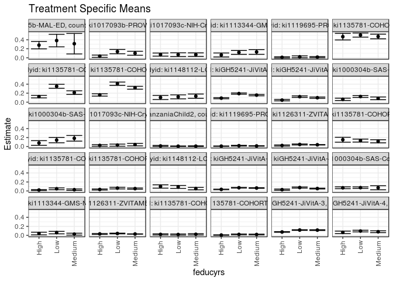

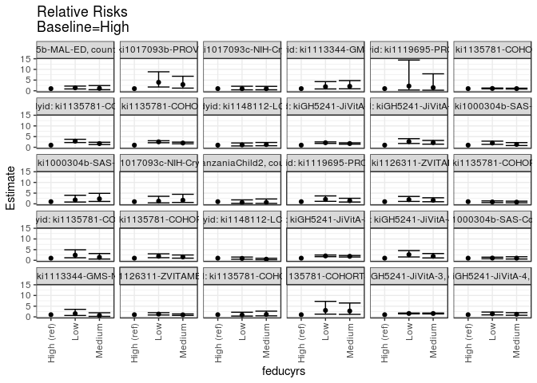

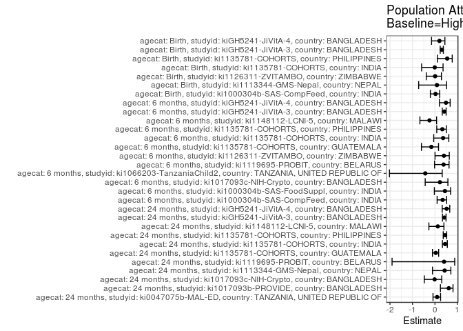

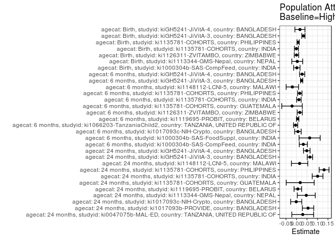

## Results Table

### Parameter: TSM

| agecat | studyid | country | intervention_level | baseline_level | estimate | ci_lower | ci_upper |
| --- | --- | --- | --- | --- | --- | --- | --- |
| Birth | ki1000304b-SAS-CompFeed | INDIA | High | NA | 0.0702341 | 0.0495776 | 0.0908906 |
| Birth | ki1000304b-SAS-CompFeed | INDIA | Low | NA | 0.0736648 | 0.0567378 | 0.0905918 |
| Birth | ki1000304b-SAS-CompFeed | INDIA | Medium | NA | 0.0712531 | 0.0269980 | 0.1155081 |
| Birth | ki1113344-GMS-Nepal | NEPAL | High | NA | 0.0406977 | 0.0111475 | 0.0702478 |
| Birth | ki1113344-GMS-Nepal | NEPAL | Low | NA | 0.0608108 | 0.0335661 | 0.0880555 |
| Birth | ki1113344-GMS-Nepal | NEPAL | Medium | NA | 0.0265487 | 0.0055745 | 0.0475229 |
| Birth | ki1126311-ZVITAMBO | ZIMBABWE | High | NA | 0.0315682 | 0.0206320 | 0.0425045 |
| Birth | ki1126311-ZVITAMBO | ZIMBABWE | Low | NA | 0.0407716 | 0.0326556 | 0.0488876 |
| Birth | ki1126311-ZVITAMBO | ZIMBABWE | Medium | NA | 0.0297910 | 0.0264977 | 0.0330843 |
| Birth | ki1135781-COHORTS | INDIA | High | NA | 0.0208729 | 0.0086629 | 0.0330828 |
| Birth | ki1135781-COHORTS | INDIA | Low | NA | 0.0182232 | 0.0057064 | 0.0307401 |
| Birth | ki1135781-COHORTS | INDIA | Medium | NA | 0.0231959 | 0.0082128 | 0.0381790 |
| Birth | ki1135781-COHORTS | PHILIPPINES | High | NA | 0.0068160 | 0.0017831 | 0.0118489 |
| Birth | ki1135781-COHORTS | PHILIPPINES | Low | NA | 0.0205562 | 0.0108839 | 0.0302286 |
| Birth | ki1135781-COHORTS | PHILIPPINES | Medium | NA | 0.0186457 | 0.0103388 | 0.0269526 |
| Birth | kiGH5241-JiVitA-3 | BANGLADESH | High | NA | 0.0746932 | 0.0664582 | 0.0829282 |
| Birth | kiGH5241-JiVitA-3 | BANGLADESH | Low | NA | 0.1175539 | 0.1107429 | 0.1243648 |
| Birth | kiGH5241-JiVitA-3 | BANGLADESH | Medium | NA | 0.1164199 | 0.1082785 | 0.1245613 |
| Birth | kiGH5241-JiVitA-4 | BANGLADESH | High | NA | 0.0670103 | 0.0393053 | 0.0947153 |
| Birth | kiGH5241-JiVitA-4 | BANGLADESH | Low | NA | 0.0952813 | 0.0770503 | 0.1135123 |
| Birth | kiGH5241-JiVitA-4 | BANGLADESH | Medium | NA | 0.0804924 | 0.0600118 | 0.1009730 |
| 6 months | ki1000304b-SAS-CompFeed | INDIA | High | NA | 0.0632184 | 0.0371438 | 0.0892930 |
| 6 months | ki1000304b-SAS-CompFeed | INDIA | Low | NA | 0.1254545 | 0.1048049 | 0.1461041 |
| 6 months | ki1000304b-SAS-CompFeed | INDIA | Medium | NA | 0.0850575 | 0.0544578 | 0.1156572 |
| 6 months | ki1000304b-SAS-FoodSuppl | INDIA | High | NA | 0.0792079 | 0.0264698 | 0.1319460 |
| 6 months | ki1000304b-SAS-FoodSuppl | INDIA | Low | NA | 0.1439394 | 0.0839775 | 0.2039013 |
| 6 months | ki1000304b-SAS-FoodSuppl | INDIA | Medium | NA | 0.1836735 | 0.1209952 | 0.2463517 |
| 6 months | ki1017093c-NIH-Crypto | BANGLADESH | High | NA | 0.0250896 | 0.0067251 | 0.0434541 |
| 6 months | ki1017093c-NIH-Crypto | BANGLADESH | Low | NA | 0.0313901 | 0.0084883 | 0.0542920 |
| 6 months | ki1017093c-NIH-Crypto | BANGLADESH | Medium | NA | 0.0422535 | 0.0152190 | 0.0692881 |

[output cut: 60 more lines]

### Parameter: E(Y)

| agecat | studyid | country | intervention_level | baseline_level | estimate | ci_lower | ci_upper |
| --- | --- | --- | --- | --- | --- | --- | --- |
| Birth | ki1000304b-SAS-CompFeed | INDIA | NA | NA | 0.0720576 | 0.0515501 | 0.0925652 |
| Birth | ki1113344-GMS-Nepal | NEPAL | NA | NA | 0.0446686 | 0.0292885 | 0.0600487 |
| Birth | ki1126311-ZVITAMBO | ZIMBABWE | NA | NA | 0.0317754 | 0.0288166 | 0.0347342 |
| Birth | ki1135781-COHORTS | INDIA | NA | NA | 0.0206795 | 0.0130966 | 0.0282623 |
| Birth | ki1135781-COHORTS | PHILIPPINES | NA | NA | 0.0149669 | 0.0105263 | 0.0194076 |
| Birth | kiGH5241-JiVitA-3 | BANGLADESH | NA | NA | 0.1077969 | 0.1031162 | 0.1124775 |
| Birth | kiGH5241-JiVitA-4 | BANGLADESH | NA | NA | 0.0835766 | 0.0713713 | 0.0957819 |
| 6 months | ki1000304b-SAS-CompFeed | INDIA | NA | NA | 0.0960240 | 0.0777684 | 0.1142796 |
| 6 months | ki1000304b-SAS-FoodSuppl | INDIA | NA | NA | 0.1421053 | 0.1069532 | 0.1772573 |
| 6 months | ki1017093c-NIH-Crypto | BANGLADESH | NA | NA | 0.0321678 | 0.0192256 | 0.0451101 |
| 6 months | ki1066203-TanzaniaChild2 | TANZANIA, UNITED REPUBLIC OF | NA | NA | 0.0094153 | 0.0052007 | 0.0136299 |
| 6 months | ki1119695-PROBIT | BELARUS | NA | NA | 0.0148577 | 0.0096205 | 0.0200949 |
| 6 months | ki1126311-ZVITAMBO | ZIMBABWE | NA | NA | 0.0397437 | 0.0355730 | 0.0439145 |
| 6 months | ki1135781-COHORTS | GUATEMALA | NA | NA | 0.1305310 | 0.1085580 | 0.1525039 |
| 6 months | ki1135781-COHORTS | INDIA | NA | NA | 0.0317690 | 0.0225290 | 0.0410089 |
| 6 months | ki1135781-COHORTS | PHILIPPINES | NA | NA | 0.0483619 | 0.0400565 | 0.0566674 |
| 6 months | ki1148112-LCNI-5 | MALAWI | NA | NA | 0.0800493 | 0.0613726 | 0.0987259 |
| 6 months | kiGH5241-JiVitA-3 | BANGLADESH | NA | NA | 0.0593851 | 0.0553716 | 0.0633986 |
| 6 months | kiGH5241-JiVitA-4 | BANGLADESH | NA | NA | 0.0554489 | 0.0485553 | 0.0623426 |
| 24 months | ki0047075b-MAL-ED | TANZANIA, UNITED REPUBLIC OF | NA | NA | 0.3107345 | 0.2423622 | 0.3791067 |
| 24 months | ki1017093b-PROVIDE | BANGLADESH | NA | NA | 0.0899654 | 0.0666186 | 0.1133122 |
| 24 months | ki1017093c-NIH-Crypto | BANGLADESH | NA | NA | 0.0700389 | 0.0479542 | 0.0921236 |
| 24 months | ki1113344-GMS-Nepal | NEPAL | NA | NA | 0.1088296 | 0.0811421 | 0.1365171 |
| 24 months | ki1119695-PROBIT | BELARUS | NA | NA | 0.0161002 | 0.0033894 | 0.0288110 |
| 24 months | ki1135781-COHORTS | GUATEMALA | NA | NA | 0.4868952 | 0.4557757 | 0.5180146 |
| 24 months | ki1135781-COHORTS | INDIA | NA | NA | 0.2231884 | 0.2012119 | 0.2451650 |
| 24 months | ki1135781-COHORTS | PHILIPPINES | NA | NA | 0.2921348 | 0.2736026 | 0.3106670 |
| 24 months | ki1148112-LCNI-5 | MALAWI | NA | NA | 0.1190893 | 0.0924996 | 0.1456790 |
| 24 months | kiGH5241-JiVitA-3 | BANGLADESH | NA | NA | 0.1536235 | 0.1447035 | 0.1625436 |
| 24 months | kiGH5241-JiVitA-4 | BANGLADESH | NA | NA | 0.0948257 | 0.0851298 | 0.1045216 |

### Parameter: RR

| agecat | studyid | country | intervention_level | baseline_level | estimate | ci_lower | ci_upper |
| --- | --- | --- | --- | --- | --- | --- | --- |
| Birth | ki1000304b-SAS-CompFeed | INDIA | High | High | 1.0000000 | 1.0000000 | 1.0000000 |
| Birth | ki1000304b-SAS-CompFeed | INDIA | Low | High | 1.0488468 | 0.7482267 | 1.4702490 |
| Birth | ki1000304b-SAS-CompFeed | INDIA | Medium | High | 1.0145080 | 0.6139171 | 1.6764911 |
| Birth | ki1113344-GMS-Nepal | NEPAL | High | High | 1.0000000 | 1.0000000 | 1.0000000 |
| Birth | ki1113344-GMS-Nepal | NEPAL | Low | High | 1.4942085 | 0.6366137 | 3.5070858 |
| Birth | ki1113344-GMS-Nepal | NEPAL | Medium | High | 0.6523388 | 0.2230853 | 1.9075481 |
| Birth | ki1126311-ZVITAMBO | ZIMBABWE | High | High | 1.0000000 | 1.0000000 | 1.0000000 |
| Birth | ki1126311-ZVITAMBO | ZIMBABWE | Low | High | 1.2915388 | 0.8661344 | 1.9258818 |
| Birth | ki1126311-ZVITAMBO | ZIMBABWE | Medium | High | 0.9437012 | 0.6560043 | 1.3575703 |
| Birth | ki1135781-COHORTS | INDIA | High | High | 1.0000000 | 1.0000000 | 1.0000000 |
| Birth | ki1135781-COHORTS | INDIA | Low | High | 0.8730586 | 0.3541786 | 2.1521100 |
| Birth | ki1135781-COHORTS | INDIA | Medium | High | 1.1112933 | 0.4649040 | 2.6564042 |
| Birth | ki1135781-COHORTS | PHILIPPINES | High | High | 1.0000000 | 1.0000000 | 1.0000000 |
| Birth | ki1135781-COHORTS | PHILIPPINES | Low | High | 3.0158921 | 1.2564898 | 7.2389007 |
| Birth | ki1135781-COHORTS | PHILIPPINES | Medium | High | 2.7355950 | 1.1548408 | 6.4800967 |
| Birth | kiGH5241-JiVitA-3 | BANGLADESH | High | High | 1.0000000 | 1.0000000 | 1.0000000 |
| Birth | kiGH5241-JiVitA-3 | BANGLADESH | Low | High | 1.5738231 | 1.3900665 | 1.7818711 |
| Birth | kiGH5241-JiVitA-3 | BANGLADESH | Medium | High | 1.5586418 | 1.3709598 | 1.7720170 |
| Birth | kiGH5241-JiVitA-4 | BANGLADESH | High | High | 1.0000000 | 1.0000000 | 1.0000000 |
| Birth | kiGH5241-JiVitA-4 | BANGLADESH | Low | High | 1.4218903 | 0.9081710 | 2.2262019 |
| Birth | kiGH5241-JiVitA-4 | BANGLADESH | Medium | High | 1.2011946 | 0.7391475 | 1.9520713 |
| 6 months | ki1000304b-SAS-CompFeed | INDIA | High | High | 1.0000000 | 1.0000000 | 1.0000000 |
| 6 months | ki1000304b-SAS-CompFeed | INDIA | Low | High | 1.9844628 | 1.3728876 | 2.8684741 |
| 6 months | ki1000304b-SAS-CompFeed | INDIA | Medium | High | 1.3454545 | 0.8214360 | 2.2037602 |
| 6 months | ki1000304b-SAS-FoodSuppl | INDIA | High | High | 1.0000000 | 1.0000000 | 1.0000000 |
| 6 months | ki1000304b-SAS-FoodSuppl | INDIA | Low | High | 1.8172348 | 0.8285460 | 3.9857080 |
| 6 months | ki1000304b-SAS-FoodSuppl | INDIA | Medium | High | 2.3188776 | 1.0973616 | 4.9001104 |
| 6 months | ki1017093c-NIH-Crypto | BANGLADESH | High | High | 1.0000000 | 1.0000000 | 1.0000000 |
| 6 months | ki1017093c-NIH-Crypto | BANGLADESH | Low | High | 1.2511211 | 0.4451121 | 3.5166512 |
| 6 months | ki1017093c-NIH-Crypto | BANGLADESH | Medium | High | 1.6841046 | 0.6370276 | 4.4522534 |

[output cut: 60 more lines]

### Parameter: PAR

| agecat | studyid | country | intervention_level | baseline_level | estimate | ci_lower | ci_upper |
| --- | --- | --- | --- | --- | --- | --- | --- |
| Birth | ki1000304b-SAS-CompFeed | INDIA | High | NA | 0.0018235 | -0.0132258 | 0.0168729 |
| Birth | ki1113344-GMS-Nepal | NEPAL | High | NA | 0.0039709 | -0.0220469 | 0.0299888 |
| Birth | ki1126311-ZVITAMBO | ZIMBABWE | High | NA | 0.0002072 | -0.0103264 | 0.0107408 |
| Birth | ki1135781-COHORTS | INDIA | High | NA | -0.0001934 | -0.0097082 | 0.0093214 |
| Birth | ki1135781-COHORTS | PHILIPPINES | High | NA | 0.0081510 | 0.0029606 | 0.0133414 |
| Birth | kiGH5241-JiVitA-3 | BANGLADESH | High | NA | 0.0331037 | 0.0255072 | 0.0407002 |
| Birth | kiGH5241-JiVitA-4 | BANGLADESH | High | NA | 0.0165663 | -0.0074191 | 0.0405517 |
| 6 months | ki1000304b-SAS-CompFeed | INDIA | High | NA | 0.0328056 | 0.0135435 | 0.0520677 |
| 6 months | ki1000304b-SAS-FoodSuppl | INDIA | High | NA | 0.0628973 | 0.0125139 | 0.1132808 |
| 6 months | ki1017093c-NIH-Crypto | BANGLADESH | High | NA | 0.0070782 | -0.0084639 | 0.0226203 |
| 6 months | ki1066203-TanzaniaChild2 | TANZANIA, UNITED REPUBLIC OF | High | NA | -0.0040618 | -0.0143016 | 0.0061780 |
| 6 months | ki1119695-PROBIT | BELARUS | High | NA | 0.0057053 | -0.0001059 | 0.0115164 |
| 6 months | ki1126311-ZVITAMBO | ZIMBABWE | High | NA | 0.0158530 | 0.0036453 | 0.0280606 |
| 6 months | ki1135781-COHORTS | GUATEMALA | High | NA | -0.0209842 | -0.0698243 | 0.0278560 |
| 6 months | ki1135781-COHORTS | INDIA | High | NA | 0.0115484 | 0.0008060 | 0.0222908 |
| 6 months | ki1135781-COHORTS | PHILIPPINES | High | NA | 0.0158142 | 0.0053070 | 0.0263214 |
| 6 months | ki1148112-LCNI-5 | MALAWI | High | NA | -0.0195523 | -0.0491067 | 0.0100020 |
| 6 months | kiGH5241-JiVitA-3 | BANGLADESH | High | NA | 0.0247976 | 0.0194249 | 0.0301702 |
| 6 months | kiGH5241-JiVitA-4 | BANGLADESH | High | NA | 0.0272415 | 0.0148768 | 0.0396061 |
| 24 months | ki0047075b-MAL-ED | TANZANIA, UNITED REPUBLIC OF | High | NA | 0.0300327 | -0.0219599 | 0.0820253 |
| 24 months | ki1017093b-PROVIDE | BANGLADESH | High | NA | 0.0553119 | 0.0281657 | 0.0824581 |
| 24 months | ki1017093c-NIH-Crypto | BANGLADESH | High | NA | -0.0010511 | -0.0275717 | 0.0254695 |
| 24 months | ki1113344-GMS-Nepal | NEPAL | High | NA | 0.0468827 | 0.0041336 | 0.0896318 |
| 24 months | ki1119695-PROBIT | BELARUS | High | NA | 0.0065308 | -0.0114833 | 0.0245449 |
| 24 months | ki1135781-COHORTS | GUATEMALA | High | NA | 0.0179686 | -0.0487249 | 0.0846621 |
| 24 months | ki1135781-COHORTS | INDIA | High | NA | 0.1007394 | 0.0752309 | 0.1262480 |
| 24 months | ki1135781-COHORTS | PHILIPPINES | High | NA | 0.1317338 | 0.1083953 | 0.1550723 |
| 24 months | ki1148112-LCNI-5 | MALAWI | High | NA | 0.0150431 | -0.0239967 | 0.0540828 |
| 24 months | kiGH5241-JiVitA-3 | BANGLADESH | High | NA | 0.0642515 | 0.0515242 | 0.0769789 |
| 24 months | kiGH5241-JiVitA-4 | BANGLADESH | High | NA | 0.0492053 | 0.0335397 | 0.0648709 |

### Parameter: PAF

| agecat | studyid | country | intervention_level | baseline_level | estimate | ci_lower | ci_upper |
| --- | --- | --- | --- | --- | --- | --- | --- |
| Birth | ki1000304b-SAS-CompFeed | INDIA | High | NA | 0.0253066 | -0.2045621 | 0.2113090 |
| Birth | ki1113344-GMS-Nepal | NEPAL | High | NA | 0.0888972 | -0.7252775 | 0.5188552 |
| Birth | ki1126311-ZVITAMBO | ZIMBABWE | High | NA | 0.0065206 | -0.3869896 | 0.2883860 |
| Birth | ki1135781-COHORTS | INDIA | High | NA | -0.0093521 | -0.5922383 | 0.3601512 |
| Birth | ki1135781-COHORTS | PHILIPPINES | High | NA | 0.5445982 | 0.1054980 | 0.7681494 |
| Birth | kiGH5241-JiVitA-3 | BANGLADESH | High | NA | 0.3070933 | 0.2339741 | 0.3732331 |
| Birth | kiGH5241-JiVitA-4 | BANGLADESH | High | NA | 0.1982173 | -0.1519788 | 0.4419554 |
| 6 months | ki1000304b-SAS-CompFeed | INDIA | High | NA | 0.3416397 | 0.0960780 | 0.5204915 |
| 6 months | ki1000304b-SAS-FoodSuppl | INDIA | High | NA | 0.4426109 | -0.0267209 | 0.6974031 |
| 6 months | ki1017093c-NIH-Crypto | BANGLADESH | High | NA | 0.2200405 | -0.4347783 | 0.5760064 |
| 6 months | ki1066203-TanzaniaChild2 | TANZANIA, UNITED REPUBLIC OF | High | NA | -0.4314087 | -2.0243888 | 0.3225306 |
| 6 months | ki1119695-PROBIT | BELARUS | High | NA | 0.3839944 | -0.0166118 | 0.6267376 |
| 6 months | ki1126311-ZVITAMBO | ZIMBABWE | High | NA | 0.3988793 | 0.0025079 | 0.6377454 |
| 6 months | ki1135781-COHORTS | GUATEMALA | High | NA | -0.1607601 | -0.6013875 | 0.1586271 |
| 6 months | ki1135781-COHORTS | INDIA | High | NA | 0.3635110 | -0.0554599 | 0.6161690 |
| 6 months | ki1135781-COHORTS | PHILIPPINES | High | NA | 0.3269976 | 0.0800067 | 0.5076788 |
| 6 months | ki1148112-LCNI-5 | MALAWI | High | NA | -0.2442538 | -0.6694251 | 0.0726344 |
| 6 months | kiGH5241-JiVitA-3 | BANGLADESH | High | NA | 0.4175722 | 0.3246698 | 0.4976943 |
| 6 months | kiGH5241-JiVitA-4 | BANGLADESH | High | NA | 0.4912893 | 0.2001205 | 0.6764680 |
| 24 months | ki0047075b-MAL-ED | TANZANIA, UNITED REPUBLIC OF | High | NA | 0.0966507 | -0.0868678 | 0.2491820 |
| 24 months | ki1017093b-PROVIDE | BANGLADESH | High | NA | 0.6148134 | 0.2437471 | 0.8038107 |
| 24 months | ki1017093c-NIH-Crypto | BANGLADESH | High | NA | -0.0150079 | -0.4739241 | 0.3010217 |
| 24 months | ki1113344-GMS-Nepal | NEPAL | High | NA | 0.4307898 | -0.1085570 | 0.7077279 |
| 24 months | ki1119695-PROBIT | BELARUS | High | NA | 0.4056353 | -1.9090987 | 0.8785640 |
| 24 months | ki1135781-COHORTS | GUATEMALA | High | NA | 0.0369045 | -0.1103115 | 0.1646011 |
| 24 months | ki1135781-COHORTS | INDIA | High | NA | 0.4513650 | 0.3317426 | 0.5495741 |
| 24 months | ki1135781-COHORTS | PHILIPPINES | High | NA | 0.4509350 | 0.3682304 | 0.5228128 |
| 24 months | ki1148112-LCNI-5 | MALAWI | High | NA | 0.1263176 | -0.2701242 | 0.3990187 |
| 24 months | kiGH5241-JiVitA-3 | BANGLADESH | High | NA | 0.4182403 | 0.3324569 | 0.4929999 |
| 24 months | kiGH5241-JiVitA-4 | BANGLADESH | High | NA | 0.5189023 | 0.3222136 | 0.6585133 |